# Per-coverage caller calibration on simulated TeoNAM truth

- Show All Code
- Hide All Code
- View Source

Choosing each ancestry caller’s parameter by coverage — minimum donor-fragment FDR against a BC1S4 simulation on the 118K v5 grid

Author

Fausto Rodríguez-Zapata

Published

July 10, 2026

**What this is.** The coverage-degradation GWAS sweep is only *fair* if each ancestry caller runs at its **per-coverage optimal parameter**. This note is the calibration that produces those parameters: for each caller and each coverage $\lambda$ we simulate a known-truth NIL panel, degrade it to $\lambda$ with the same read model the sweep uses, sweep the caller’s one segmentation parameter, and pick the value that **minimizes the donor-fragment false-discovery rate**.

**NoteMethod (identical across callers)**

1. **Simulated ground truth** — `simulate_nil("BC1S4", n = 200, map = <118K v5 cM grid>, seed = 12345)`, with known crossovers. Truth is *simulated*, never a real family’s caller output (that would score a caller against another caller).
2. **Degrade** with the sweep’s read model — `.draw_counts(state, λ, error = 0.01)`, same seeds — at $\lambda \in \{0.1, 0.2, 0.5, 1, 5, 10, 20, \infty\}$ ($\infty$ = deterministic depth-100).
3. **Sweep** the caller’s single parameter and **score** each fit against truth.
4. **Pick** by **minimum `donor_frag_FDR`** (fewest spurious donor fragments), at `min_reads = 1`. Donor recall stays $\approx 0.99$–$1.0$ throughout, so recall does not discriminate — FDR does.

The three callers differ only in the segmentation parameter and whether it is map-aware:

| caller | parameter | type | map-aware? |
| --- | --- | --- | --- |
| **RTIGER** | `rigidity` | integer — minimum run length in **markers** | no (index-based) |
| **nNIL** | `rrate` | continuous — per-marker recombination rate (self-stay $= 1-$`rrate`) | **no** (one fixed transition every marker) |
| **LB-Impute** | `recombdist` | continuous — linkage-decay **distance (cM)** | **yes** (consumes the cM gaps) |

```r
suppressMessages({
  library(here)
  library(data.table)
  library(ggplot2)
})

COVS <- c("0.1", "0.2", "0.5", "1", "5", "10", "20", "Inf")
read_pick <- function(caller) {
  d <- fread(here(sprintf("results/sim/teonam/%s_calib_bycov.csv", caller)))
  setnames(d, tolower(names(d)))
  parm <- intersect(c("rigidity", "rrate", "recombdist"), names(d))
  data.table(
    caller = caller, coverage = as.character(d$coverage),
    param = parm, param_value = d[[parm]],
    fdr = d[["fdr"]], recall = d[["recall"]], dice = d[["dice"]]
  )
}
picks <- rbindlist(lapply(c("rtiger", "nnil", "lbimpute"), read_pick))
picks[, coverage := factor(coverage, levels = COVS)]
picks[, caller := factor(caller, levels = c("rtiger", "nnil", "lbimpute"))]

curves <- rbindlist(lapply(c("rtiger", "nnil", "lbimpute"), function(c) {
  d <- fread(here(sprintf("results/sim/teonam/%s_calib_bycov_sweep.csv", c)))
  d[, caller := c]
  d
}), fill = TRUE)
curves[, coverage := factor(as.character(coverage), levels = COVS)]
curves[, caller := factor(caller, levels = c("rtiger", "nnil", "lbimpute"))]
```

# The chosen parameter by coverage

`param*(λ)`, the value carried into the sweep at each coverage. Each caller’s parameter lives on a different scale, so the panels have independent $y$-axes.

```r
knitr::kable(
  dcast(picks, coverage ~ caller, value.var = "param_value"),
  caption = "param*(λ): rigidity (RTIGER), rrate (nNIL), recombdist cM (LB-Impute)."
)
```

param*(λ): rigidity (RTIGER), rrate (nNIL), recombdist cM (LB-Impute).

| coverage | rtiger | nnil | lbimpute |
| --- | --- | --- | --- |
| 0.1 | 16 | 0.0000575 | 61.660 |
| 0.2 | 16 | 0.0000774 | 138.800 |
| 0.5 | 32 | 0.0000214 | 13.580 |
| 1 | 64 | 0.0002030 | 10.680 |
| 5 | 64 | 0.0002129 | 24.880 |
| 10 | 64 | 0.0000171 | 8.224 |
| 20 | 64 | 0.0000171 | 8.224 |
| Inf | 128 | 0.0000171 | 8.224 |

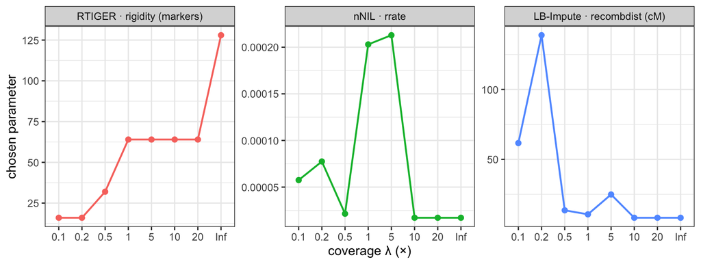

```r
ggplot(picks, aes(coverage, param_value, group = caller, colour = caller)) +
  geom_line(linewidth = 0.8) +
  geom_point(size = 2) +
  facet_wrap(~caller, scales = "free_y",
    labeller = as_labeller(c(
      rtiger = "RTIGER · rigidity (markers)",
      nnil = "nNIL · rrate",
      lbimpute = "LB-Impute · recombdist (cM)"
    ))
  ) +
  labs(x = "coverage λ (×)", y = "chosen parameter", colour = NULL) +
  theme_bw(base_size = 12) +
  theme(legend.position = "none")
```

- **RTIGER `rigidity` rises with coverage** (16 → 128): deeper coverage exposes more per-marker detail, so a longer minimum run is needed to keep segments stable.
- **LB-Impute `recombdist`** is high at the lowest coverages (stiffer, longer segments compensate for sparse reads) and settles to $\approx 8$–25 cM once coverage is informative.
- **nNIL `rrate` does not trend** — it bounces over an order of magnitude. That is not signal; see the flat FDR plateau below.

# Why each pick — FDR against the parameter

The selection objective, `donor_frag_FDR`, as a function of the swept parameter, one line per coverage. The chosen parameter is the curve’s minimum.

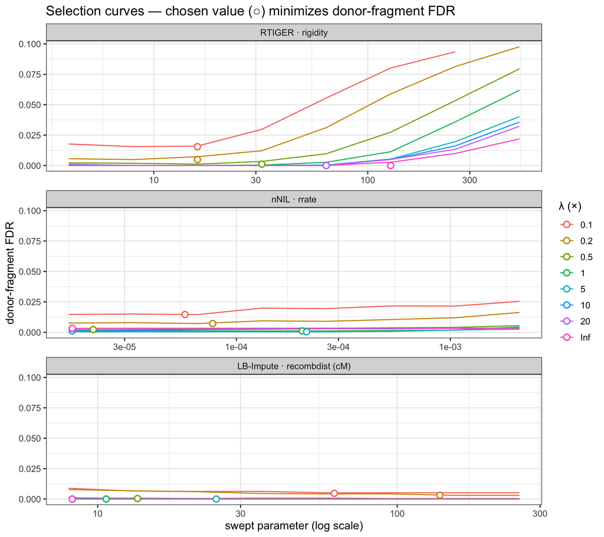

```r
# Mark each pick at its own recorded (param*, FDR*) — robust to golden-refined
# values that need not sit on the coarse swept grid.
mark <- picks[, .(caller, coverage, value = param_value, donor_frag_FDR = fdr)]

ggplot(curves, aes(value, donor_frag_FDR, colour = coverage, group = coverage)) +
  geom_line() +
  geom_point(data = mark, size = 2.4, shape = 21, fill = "white", stroke = 1) +
  facet_wrap(~caller, ncol = 1, scales = "free_x",
    labeller = as_labeller(c(
      rtiger = "RTIGER · rigidity", nnil = "nNIL · rrate",
      lbimpute = "LB-Impute · recombdist (cM)"
    ))
  ) +
  scale_x_log10() +
  labs(
    x = "swept parameter (log scale)", y = "donor-fragment FDR",
    colour = "λ (×)",
    title = "Selection curves — chosen value (○) minimizes donor-fragment FDR"
  ) +
  theme_bw(base_size = 12)
```

**nNIL is a flat low-`rrate` plateau.** Across the whole low-`rrate` range the FDR barely moves (recall is already $\approx 1$), so the “minimum” is essentially noise — which is why the per-coverage `rrate*` bounces around above. The operational decision is therefore to run nNIL at a **single fixed `rrate` = 3.3e-5** in the sweep rather than the per-coverage argmin; RTIGER and LB-Impute do carry their per-coverage values.

# Recall is not the discriminating metric

Donor-marker recall is saturated ($\approx 0.99$–$1.0$) at every coverage and parameter, confirming that `donor_frag_FDR` — not recall — is what separates a good parameter from a bad one.

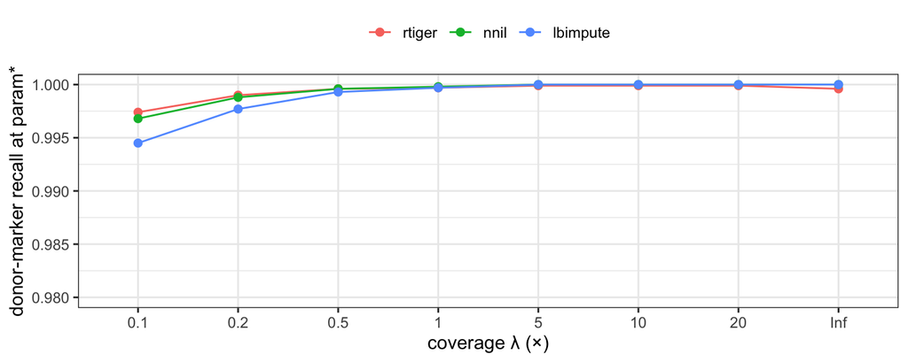

```r
ggplot(picks, aes(coverage, recall, group = caller, colour = caller)) +
  geom_line() +
  geom_point(size = 2) +
  scale_y_continuous(limits = c(0.98, 1)) +
  labs(x = "coverage λ (×)", y = "donor-marker recall at param*", colour = NULL) +
  theme_bw(base_size = 12) +
  theme(legend.position = "top")
```

# Bottom line

The calibration gives each caller a coverage-matched parameter for the degradation sweep: RTIGER’s `rigidity` climbs 16 → 128 with depth, LB-Impute’s `recombdist` settles near 8–25 cM, and nNIL’s FDR plateau means a single fixed `rrate` is the honest choice. All three hold donor recall at $\approx 1$; the tuning only trades off spurious donor fragments (FDR). Parameters are read from `results/sim/teonam/{rtiger,nnil,lbimpute}_calib_bycov.csv`; the full selection curves are in the `_calib_bycov_sweep.csv` companions.